# R Notebook

# 3.7 Vectors

complex datasets can usually be broken down into components that are vectors

# 3.7.1 Creating Vectors

create vectors using function ‘c’

```r
codes <- c(380, 124, 818)
codes
```

```
[1] 380 124 818
```

create character vectors

```r
country <- c("italy", "canada", "egypt")
```

```r
country <- c('italy', 'canada', 'egypt')
```

don’t use back quote!

```r
country <- c(italy, canada, egypt)
```

```
Error: object 'italy' not found
```

this code will show error - not defined!

# 3.7.2 Names

sometimes it’s useful to name entries

```r
codes <- c(italy = 380, canada = 124, egypt = 818)
codes
```

```
 italy canada  egypt
   380    124    818
```

still numeric vector

```r
class(codes)
```

```
[1] "numeric"
```

but with names

```r
names(codes)
```

```
[1] "italy"  "canada" "egypt"
```

you can use quotes as well

```r
codes <- c("italy" = 380, "canada" = 124, "egypt" = 818)
codes
```

```
 italy canada  egypt
   380    124    818
```

we can also assign names using names functions

```r
codes <- c(380, 124, 818)
country <- c("italy","canada","egypt")
names(codes) <- country
codes
```

```
 italy canada  egypt
   380    124    818
```

# 3.7.3 Sequences

```r
seq(1, 10)
```

```
 [1]  1  2  3  4  5  6  7  8  9 10
```

first argument defines the start, second defines the end default: increase 1, third argument - how much to jump by

```r
seq(1, 10, 2)
```

```
[1] 1 3 5 7 9
```

consecutive integers;

```r
1:10
```

```
 [1]  1  2  3  4  5  6  7  8  9 10
```

r produces integers, not numerics! cuz they are typically used to index sth

```r
class(1:10)
```

```
[1] "integer"
```

if we create sequence including non-integers,

```r
class(seq(1,10,0.5))
```

```
[1] "numeric"
```

# 3.7.4 Subsetting

square brackets : to access specific elements

```r
codes[2]
```

```
canada
   124
```

get more than one entry

```r
codes[c(1,3)]
```

```
italy egypt
  380   818
```

the sequences

```r
codes[1:2]
```

```
 italy canada
   380    124
```

if the elements have names, we can access by using names

```r
codes["canada"]
```

```
canada
   124
```

```r
codes[c("egypt","italy")]
```

```
egypt italy
  818   380
```

# 3.8 Coercion

Attempt by R to be flexible with data types vectors must be all of the same type. So combining numbers and characters is expected to make an error

```r
x <- c(1, "canada", 3)
```

```r
x
```

```
[1] "1"      "canada" "3"
```

```r
class(x)
```

```
[1] "character"
```

R corrected the data into characters. coercion can cause many unnoticed errors in R

R also ofers functions to chance from one type to another

```r
x <- 1:5
y <- as.character(x)
y
```

```
[1] "1" "2" "3" "4" "5"
```

you can turn back by using as.numeric

```r
as.numeric(y)
```

```
[1] 1 2 3 4 5
```

# 3.8.1 Not availables (NA)

function tries to coerce different types in an impossible case, gives a warning ‘NA’

```r
x <- c("1", "b", "3")
as.numeric(x)
```

[output not shown]

NA is often as they are used for missing data

# 3.9 Exercises

Q1. Use the function c to create a vector with the average high temperatures in January for Beijing, Lagos, Paris, Rio de Janeiro, San Juan and Toronto, which are 35, 88, 42, 84, 81, and 30 degrees Fahrenheit. Call the object temp.

```r
temp
```

```
[1] 35 88 42 84 81 30
```

Q2. Create a vector with the city names and call the object city

```r
city<- c("Beijing", "Lagos", "Paris", "Rio de Janeiro", "San Juan", "Toronto")
city
```

```
[1] "Beijing"        "Lagos"
[3] "Paris"          "Rio de Janeiro"
[5] "San Juan"       "Toronto"
```

Q3. Use the names function and the objects defined in the previous exercises to associate the temperature data with its corresponding city.

```r
names(temp) <- city
temp
```

```
       Beijing          Lagos          Paris
            35             88             42
Rio de Janeiro       San Juan        Toronto
            84             81             30
```

Q4. Use the [ and : operators to access the temperature of the first three cities on the list.

```r
temp[1:3]
```

```
Beijing   Lagos   Paris
     35      88      42
```

Q5. Use the [ operator to access the temperature of Paris and San Juan.

```r
temp[c("Paris", "San Juan")]
```

```
   Paris San Juan
      42       81
```

Q6. Use the : operator to create a sequence of numbers 12, 13, … 73.

```r
seq(12, 73)
```

```
 [1] 12 13 14 15 16 17 18 19 20 21 22 23 24 25 26
[16] 27 28 29 30 31 32 33 34 35 36 37 38 39 40 41
[31] 42 43 44 45 46 47 48 49 50 51 52 53 54 55 56
[46] 57 58 59 60 61 62 63 64 65 66 67 68 69 70 71
[61] 72 73
```

Q7. Create a vector containing all the positive odd numbers smaller than 100.

```r
seq(1, 100, 2)
```

```
 [1]  1  3  5  7  9 11 13 15 17 19 21 23 25 27 29
[16] 31 33 35 37 39 41 43 45 47 49 51 53 55 57 59
[31] 61 63 65 67 69 71 73 75 77 79 81 83 85 87 89
[46] 91 93 95 97 99
```

Q8. Create a vector of numbers that starts at 6, does not pass 55, and adds numbers in increments of 4/7: 6, 6+4/7, 6+8/7, etc.. How many numbers does the list have? Hint: use seq and length.

```r
incr47 <- seq(6, 55, 4/7)
incr47
```

```
 [1]  6.000000  6.571429  7.142857  7.714286
 [5]  8.285714  8.857143  9.428571 10.000000
 [9] 10.571429 11.142857 11.714286 12.285714
[13] 12.857143 13.428571 14.000000 14.571429
[17] 15.142857 15.714286 16.285714 16.857143
[21] 17.428571 18.000000 18.571429 19.142857
[25] 19.714286 20.285714 20.857143 21.428571
[29] 22.000000 22.571429 23.142857 23.714286
[33] 24.285714 24.857143 25.428571 26.000000
[37] 26.571429 27.142857 27.714286 28.285714
[41] 28.857143 29.428571 30.000000 30.571429
[45] 31.142857 31.714286 32.285714 32.857143
[49] 33.428571 34.000000 34.571429 35.142857
[53] 35.714286 36.285714 36.857143 37.428571
[57] 38.000000 38.571429 39.142857 39.714286
[61] 40.285714 40.857143 41.428571 42.000000
[65] 42.571429 43.142857 43.714286 44.285714
[69] 44.857143 45.428571 46.000000 46.571429
[73] 47.142857 47.714286 48.285714 48.857143
[77] 49.428571 50.000000 50.571429 51.142857
[81] 51.714286 52.285714 52.857143 53.428571
[85] 54.000000 54.571429
```

```r
length(incr47)
```

```
[1] 86
```

Q9. What is the class of the following object a <- seq(1, 10, 0.5)?

```r
a<- seq(1, 10, 0.5)
class(a)
```

```
[1] "numeric"
```

Q10. What is the class of the following object a <- seq(1, 10)?

```r
a<- seq(1, 10)
class(a)
```

```
[1] "integer"
```

Q11. The class of class(a<-1) is numeric, not integer. R defaults to numeric and to force an integer, you need to add the letter L. Confirm that the class of 1L is integer.

```r
class(a<-1L)
```

```
[1] "integer"
```

Q12.

```r
x <- c("1", "3", "5")
```

correct it to get integers

```r
as.integer(x)
```

```
[1] 1 3 5
```

# 3.10 Sorting

Let’s gain some insights! YEY!

# 3.10.1 sort

Rank the states from least to must gun murders function ‘sort’ sorts a vector in increasing order

```r
library(dslabs)
data(murders)
sort(murders$total)
```

```
 [1]    2    4    5    5    7    8   11   12   12
[10]   16   19   21   22   27   32   36   38   53
[19]   63   65   67   84   93   93   97   97   99
[28]  111  116  118  120  135  142  207  219  232
[37]  246  250  286  293  310  321  351  364  376
[46]  413  457  517  669  805 1257
```

this does not give info about states

# 3.10.2 order

function ‘order’ takes vector as input and returns vector of indexes that sorts the input vector

```r
x <- c(31, 4, 15, 92, 65)
sort(x)
```

```
[1]  4 15 31 65 92
```

the function ‘order’ returns index that sorts input vector

```r
index <- order(x)
x[index]
```

```
[1]  4 15 31 65 92
```

this is the same output.

```r
x
```

```
[1] 31  4 15 92 65
```

```r
order(x)
```

```
[1] 2 3 1 5 4
```

second entry of x is smallest or ‘order(x)’ starts with 2.

entries of vectors you access with ‘$’ follow the same order as the rows in the table

```r
murders$state[1:10]
```

```
 [1] "Alabama"              "Alaska"
 [3] "Arizona"              "Arkansas"
 [5] "California"           "Colorado"
 [7] "Connecticut"          "Delaware"
 [9] "District of Columbia" "Florida"
```

```r
murders$abb[1:10]
```

```
 [1] "AL" "AK" "AZ" "AR" "CA" "CO" "CT" "DE" "DC"
[10] "FL"
```

we can order the state names by their total numbers

```r
murders$abb[ind]
```

```
 [1] "VT" "ND" "NH" "WY" "HI" "SD" "ME" "ID" "MT"
[10] "RI" "AK" "IA" "UT" "WV" "NE" "OR" "DE" "MN"
[19] "KS" "CO" "NM" "NV" "AR" "WA" "CT" "WI" "DC"
[28] "OK" "KY" "MA" "MS" "AL" "IN" "SC" "TN" "AZ"
[37] "NJ" "VA" "NC" "MD" "OH" "MO" "LA" "IL" "GA"
[46] "MI" "PA" "NY" "FL" "TX" "CA"
```

california has the most murders!

# 3.10.3 max and which.max

largest value: ‘max’

```r
max(murders$total)
```

```
[1] 1257
```

‘which.max’ for the index of the largest value

```r
i_max <- which.max(murders$total)
murders$state[i_max]
```

```
[1] "California"
```

for the minimum, use ‘min’ and ‘which.min’ in the same way we should consider rates instead of totals ; ‘rank’

# 3.10.4 rank

‘rank’ returns a vector with the rank of the first entry, second entry, etc., of the input vector

```r
x<- c(31, 4, 15, 92, 65)
rank(x)
```

```
[1] 3 1 2 5 4
```

# 3.10.5 Beware of Recycling

if the vectors don’t match in the length, it is natural to assume that we must get an error : but it doesn’t happen

```r
x <- c(1,2,3)
y <- c(10, 20, 30, 40, 50, 60, 70)
x+y
```

```
longer object length is not a multiple of shorter object length
```

```
[1] 11 22 33 41 52 63 71
```

we do get warning but not error R recycles numbers in x

# 3.11 Exercise

We’ll be using US murders dataset

```r
library(dslabs)
data("murders")
```

Q1. Use the $ operator to access the population size data and store it as the object pop. Then use the sort function to redefine pop so that it is sorted. Finally, use the [ operator to report the smallest population size.

```r
pop[1]
```

```
[1] 563626
```

Q2. find the index of the entry with the smallest population size. Hint: use order instead of sort.

```r
pop1 <- order(murders$population)
murders$state[pop1]
```

```
 [1] "Wyoming"              "District of Columbia"
 [3] "Vermont"              "North Dakota"
 [5] "Alaska"               "South Dakota"
 [7] "Delaware"             "Montana"
 [9] "Rhode Island"         "New Hampshire"
[11] "Maine"                "Hawaii"
[13] "Idaho"                "Nebraska"
[15] "West Virginia"        "New Mexico"
[17] "Nevada"               "Utah"
[19] "Kansas"               "Arkansas"
[21] "Mississippi"          "Iowa"
[23] "Connecticut"          "Oklahoma"
[25] "Oregon"               "Kentucky"
[27] "Louisiana"            "South Carolina"
[29] "Alabama"              "Colorado"
[31] "Minnesota"            "Wisconsin"
[33] "Maryland"             "Missouri"
[35] "Tennessee"            "Arizona"
[37] "Indiana"              "Massachusetts"
[39] "Washington"           "Virginia"
[41] "New Jersey"           "North Carolina"
[43] "Michigan"             "Georgia"
[45] "Ohio"                 "Pennsylvania"
[47] "Illinois"             "New York"
[49] "Florida"              "Texas"
[51] "California"
```

Q3. same operation as in the previous exercise using the function which.min. Write one line of code that does this.

```r
murders$state[which.min(murders$population)]
```

```
[1] "Wyoming"
```

Q4. You know the smallest state/which row represents it. Which state is it? Define a variable states to be the state names from the murders data frame. Report the name of the state with the smallest population.

```r
mstates[51]
```

```
[1] "Wyoming"
```

Q5. Create a data frame using the data.frame function.

```r
temp <- c(35, 88, 42, 84, 81, 30)
city <- c("Beijing", "Lagos", "Paris", "Rio de Janeiro", "San Juan", "Toronto")
city_temps <- data.frame(name = city, temperature = temp)
```

Use the rank function to determine the population rank of each state from smallest population size to biggest. Save these ranks in an object called ranks, then create a data frame with the state name and its rank. Call the data frame my_df.

| name | population_rankfrom_smallest |
| --- | --- |
| Alabama | 29 |
| Alaska | 5 |
| Arizona | 36 |
| Arkansas | 20 |
| California | 51 |
| Colorado | 30 |
| Connecticut | 23 |
| Delaware | 7 |
| District of Columbia | 2 |
| Florida | 49 |

[output cut: 41 more lines]

Q6. Repeat the previous exercise, but this time order my_df so that the states are ordered from least populous to most populous. Hint: create an object ind that stores the indexes needed to order the population values. Then use the bracket operator [ to re-order each column in the data frame.

| name | population |
| --- | --- |
| Wyoming | 51 |
| District of Columbia | 9 |
| Vermont | 46 |
| North Dakota | 35 |
| Alaska | 2 |
| South Dakota | 42 |
| Delaware | 8 |
| Montana | 27 |
| Rhode Island | 40 |
| New Hampshire | 30 |

[output cut: 41 more lines]

Q7. The na_example vector represents a series of counts.

```r
str(na_example)
```

```
 int [1:1000] 2 1 3 2 1 3 1 4 3 2 ...
```

the function mean, we obtain an NA

```r
mean(na_example)
```

```
[1] NA
```

is.na function returns a logical vector that tells us which entries are NA. Assign this logical vector to an object called ind and determine how many NAs does na_example have.

```r
ind
```

```
   [1] FALSE FALSE FALSE FALSE FALSE FALSE
   [7] FALSE FALSE FALSE FALSE FALSE  TRUE
  [13] FALSE FALSE FALSE FALSE  TRUE FALSE
  [19] FALSE FALSE FALSE FALSE FALSE FALSE
  [25] FALSE FALSE  TRUE FALSE FALSE FALSE
  [31] FALSE FALSE FALSE FALSE FALSE FALSE
  [37] FALSE FALSE FALSE FALSE FALSE FALSE
  [43] FALSE FALSE FALSE FALSE FALSE FALSE
  [49] FALSE  TRUE  TRUE  TRUE FALSE FALSE
  [55] FALSE FALSE FALSE FALSE  TRUE FALSE
  [61] FALSE FALSE FALSE FALSE  TRUE  TRUE
  [67] FALSE  TRUE FALSE FALSE FALSE FALSE
  [73] FALSE FALSE FALSE FALSE FALSE FALSE
  [79] FALSE FALSE FALSE FALSE FALSE FALSE
  [85] FALSE FALSE FALSE FALSE FALSE FALSE
```

[output cut: 152 more lines]

Q8. Now compute the average again, but only for the entries that are not NA. Hint: remember the ! operator.

```r
mean(na_example[!ind])
```

```
[1] 2.301754
```

# 3.12 Vector Arithmetics

California; many ppl than other states?

```r
library(dslabs)
data("murders")
murders$state[which.max(murders$population)]
```

```
[1] "California"
```

unfair to compare just the totals! we need murders per capita

# 3.12.1 Rescaling a vector

Arithmetic operations on vectors; occur element-wise suppose we have height in inches:

```r
inches <- c(69, 62, 66, 70, 70, 73, 67, 73, 67, 70)
```

and want to convert to centimeters multiple 2.54

```r
inches * 2.54
```

```
 [1] 175.26 157.48 167.64 177.80 177.80
 [6] 185.42 170.18 185.42 170.18 177.80
```

Similarly, if for each entry we want to compute how many inches taller or shorter than 69 inches, the average height for males, we can subtract it from every entry like this

```r
inches-69
```

```
 [1]  0 -7 -3  1  1  4 -2  4 -2  1
```

# 3.12.2 Two vectors

If we have two vectors of same length and sum, (a, b, c) + (d, e, f) = (a+d, b+e, c+f)

```r
murder_rate <- murders$total / murders$population * 100000
```

California is no longer near the top of the list

```r
murders$state[order(murder_rate)]
```

```
 [1] "Vermont"
 [2] "New Hampshire"
 [3] "Hawaii"
 [4] "North Dakota"
 [5] "Iowa"
 [6] "Idaho"
 [7] "Utah"
 [8] "Maine"
 [9] "Wyoming"
[10] "Oregon"
[11] "South Dakota"
[12] "Minnesota"
[13] "Montana"
[14] "Colorado"
[15] "Washington"
```

[output cut: 36 more lines]

# 3.13 Exercises

Q1. previously

```r
temp <- c(35, 88, 42, 84, 81, 30)
city <- c("Beijing", "Lagos", "Paris", "Rio de Janeiro", "San Juan", "Toronto")
city_temps <- data.frame(name = city, temperature = temp)
```

add a line that converts the temperature from Fahrenheit to Celsius

```r
temp1 <- 5/9*(temp-32)
city_temp1 <- data.frame(name=city, temperatureF=temp, temperatureC=temp1)
city_temp1
```

| name | temperatureF | temperatureC |
| --- | --- | --- |
| Beijing | 35 | 1.666667 |
| Lagos | 88 | 31.111111 |
| Paris | 42 | 5.555556 |
| Rio de Janeiro | 84 | 28.888889 |
| San Juan | 81 | 27.222222 |
| Toronto | 30 | -1.111111 |

```r
x <- seq(1:100)
sum(1/x^2)
```

```
[1] 1.634984
```

or

```r
sum(sumsquare(1:100))
```

```
[1] 1.634984
```

Q3.Compute the per 100,000 murder rate for each state and store it in the object murder_rate. Then compute the average murder rate for the US using the function mean. What is the average

```r
mean(murder_rate)
```

```
[1] 2.779125
```

# 3.14 Indexing

```r
library(dslabs)
data("murders")
```

# 3.14.1 Subsetting with logicals

murder rate

```r
murder_rate <- murders$total / murders$population * 100000
```

prefer to move to a state with similar murder rate we can use logicals to index vectors compare a vector to a single number; performs test for each entry

```r
ind <- murder_rate < 0.71
```

instead want to know if less or equal

```r
ind <- murder_rate <= 0.71
ind
```

```
 [1] FALSE FALSE FALSE FALSE FALSE FALSE
 [7] FALSE FALSE FALSE FALSE FALSE  TRUE
[13] FALSE FALSE FALSE  TRUE FALSE FALSE
[19] FALSE FALSE FALSE FALSE FALSE FALSE
[25] FALSE FALSE FALSE FALSE FALSE  TRUE
[31] FALSE FALSE FALSE FALSE  TRUE FALSE
[37] FALSE FALSE FALSE FALSE FALSE FALSE
[43] FALSE FALSE FALSE  TRUE FALSE FALSE
[49] FALSE FALSE FALSE
```

to see which states these are, we can leverage the fact that vectors can be indexed with logicals

```r
murders$state[ind]
```

```
[1] "Hawaii"        "Iowa"
[3] "New Hampshire" "North Dakota"
[5] "Vermont"
```

To count how many are true, function sum returns the sum of the entries of vector&logical vectors get coerced to numeric with TRUE coded as 1 and FALSE as 0.

```r
sum(ind)
```

```
[1] 5
```

# 3.14.2 Logical Operators

moving to west, want murder rate to be at most 1 2 diff. things to be true -> logical operator AND: & TRUE only when both logicals are TRUE

```r
TRUE & TRUE
```

```
[1] TRUE
```

```r
TRUE & FALSE
```

```
[1] FALSE
```

```r
FALSE & FALSE
```

```
[1] FALSE
```

```r
west <- murders$region == "West"
safe <- murder_rate <= 1
```

```r
ind <- safe & west
murders$state[ind]
```

```
[1] "Hawaii"  "Idaho"   "Oregon"  "Utah"
[5] "Wyoming"
```

# 3.14.3 which

We want to look up California’s murder rate convenient to convert vectors of logicals into indexes function which: tells us which entries of a logical vector are true

```r
ind <- which(murders$state == "California")
murder_rate[ind]
```

```
[1] 3.374138
```

# 3.14.4 match

murder rates for several states; can use function match.

```r
ind <- match(c("New York", "Florida", "Texas"), murders$state)
ind
```

```
[1] 33 10 44
```

```r
murder_rate[ind]
```

```
[1] 2.667960 3.398069 3.201360
```

# 3.14.5 %in%

We can use the function %in% to see whether or not each element of a first vector is in a second

```r
c("Boston", "Dakota", "Washington") %in% murders$state
```

```
[1] FALSE FALSE  TRUE
```

connection between match and %in% through which

```r
match(c("New York", "Florida", "Texas"), murders$state)
```

```
[1] 33 10 44
```

```r
which(murders$state%in%c("New York", "Florida", "Texas"))
```

```
[1] 10 33 44
```

# 3.15 Exercises

```r
library(dslabs)
data(murders)
```

Q1. Compute the per 100,000 murder rate for each state and store it in an object called murder_rate. Then use logical operators to create a logical vector named low that tells us which entries of murder_rate are lower than 1

```r
murder_rate <- murders$total / murders$population * 100000
low <- murder_rate < 1
low
```

```
 [1] FALSE FALSE FALSE FALSE FALSE FALSE
 [7] FALSE FALSE FALSE FALSE FALSE  TRUE
[13]  TRUE FALSE FALSE  TRUE FALSE FALSE
[19] FALSE  TRUE FALSE FALSE FALSE  TRUE
[25] FALSE FALSE FALSE FALSE FALSE  TRUE
[31] FALSE FALSE FALSE FALSE  TRUE FALSE
[37] FALSE  TRUE FALSE FALSE FALSE  TRUE
[43] FALSE FALSE  TRUE  TRUE FALSE FALSE
[49] FALSE FALSE  TRUE
```

Q2. Now use the results from the previous exercise and the function which to determine the indices of murder_rate associated with values lower than 1.

```r
which(low)
```

```
 [1] 12 13 16 20 24 30 35 38 42 45 46 51
```

Q3. Use the results from the previous exercise to report the names of the states with murder rates lower than 1.

```r
murders$state[low]
```

```
 [1] "Hawaii"        "Idaho"
 [3] "Iowa"          "Maine"
 [5] "Minnesota"     "New Hampshire"
 [7] "North Dakota"  "Oregon"
 [9] "South Dakota"  "Utah"
[11] "Vermont"       "Wyoming"
```

Q4. Now extend the code from exercise 2 and 3 to report the states in the Northeast with murder rates lower than 1. Hint: use the previously defined logical vector low and the logical operator &.

```r
northeast <- murders$region =="Northeast"
murders$state[low&northeast]
```

```
[1] "Maine"         "New Hampshire"
[3] "Vermont"
```

Q5. In a previous exercise we computed the murder rate for each state and the average of these numbers. How many states are below the average?

```r
murder_rate <- murders$total / murders$population * 100000
below <- murder_rate < mean(murder_rate)
sum(below)
```

```
[1] 27
```

Q6. Use the match function to identify the states with abbreviations AK, MI, and IA. Hint: start by defining an index of the entries of murders$abb that match the three abbreviations, then use the [ operator to extract the states.

```r
match1 <- match(c("AK", "MI", "IA"), murders$abb)
murders$state[match1]
```

```
[1] "Alaska"   "Michigan" "Iowa"
```

Q7. Use the %in% operator to create a logical vector that answers the question: which of the following are actual abbreviations: MA, ME, MI, MO, MU ?

```r
c("MA", "ME", "MI", "MO", "MU") %in% murders$abb
```

```
[1]  TRUE  TRUE  TRUE  TRUE FALSE
```

Q8. Extend the code you used in exercise 7 to report the one entry that is not an actual abbreviation. Hint: use the ! operator, which turns FALSE into TRUE and vice versa, then which to obtain an index.

```r
abb5 <- c("MA", "ME", "MI", "MO", "MU") %in% murders$abb
which(!abb5==TRUE)
```

```
[1] 5
```

# 3.16 Basic Plots

some of the functions in a basic R instlalation

# 3.16.1 plot

plot function can be used to make scatterplots

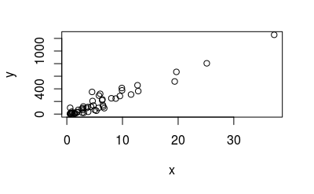

```r
x <- murders$population / 10^6
y <- murders$total

plot(x, y)
```

for a quik plot that avoids accessing variables twice, with function

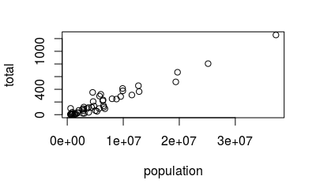

with function lets us use the murders column names in the plot function

# 3.16.2 hist

histograms; graphical summary of list of numbers

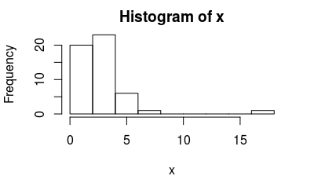

```r
x <- with(murders, total / population * 100000)
hist(x)
```

wide range of values murder rate of more than 15:

```r
murders$state[which.max(x)]
```

```
[1] "District of Columbia"
```

# 3.16.3 boxplot

boxplots - provide terse summary than histograms. easier to stack with other boxplots

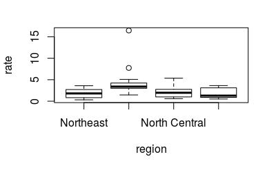

```r
murders$rate <- with(murders, total / population * 100000)
boxplot(rate~region, data = murders)
```

# 3.16.4 image

displays the values in a matrix using color

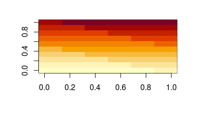

```r
x <- matrix(1:120, 12, 10)
image(x)
```

# 3.17 Exercises

Q1. states with larger populations had more murders

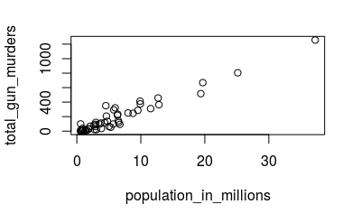

```r
library(dslabs)
data(murders)
population_in_millions <- murders$population/10^6
total_gun_murders <- murders$total
plot(population_in_millions, total_gun_murders)
```

We may gain further insights from making this plot in the log scale. Transform the variables using the log10 transformation and then plot them.

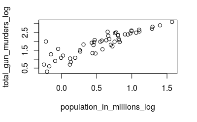

```r
population_in_millions_log <- log10(murders$population/10^6)
total_gun_murders_log <- log10(murders$total)
plot(population_in_millions_log, total_gun_murders_log)
```

Q2. Create a histogram of the state populations.

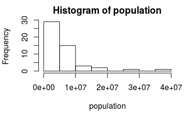

```r
population <- with(murders, population)
hist(population)
```

Q3. Generate boxplots of the state populations by region.

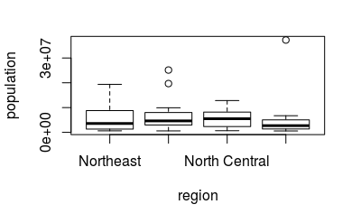